# knes381-demo2-d8d817-pythonproject

[figure not shown]

## Plotting $\dot{V}O_2$ continued...

#### Developed by Dr. John Holash at the University of Calgary

```
/kaggle/input/demo-knes381/subject_1321.xlsx
/kaggle/input/demo-knes381/subject_1432.xlsx
/kaggle/input/demo-knes381/subject_1321.csv
/kaggle/input/demo-knes381/subject_1232.csv
/kaggle/input/demo-knes381/VO2_CSV.csv
/kaggle/input/demo-knes381/subject_1232.xlsx
/kaggle/input/demo-knes381/subject_1432.csv
/kaggle/input/demo-knes381/subject_1523.csv
/kaggle/input/demo-knes381/VO2_excel.xlsx
/kaggle/input/demo-knes381/subject_1523.xlsx
```

```
<class 'pandas.core.frame.DataFrame'>
RangeIndex: 54 entries, 0 to 53
Data columns (total 16 columns):
 #   Column       Non-Null Count  Dtype
---  ------       --------------  -----
 0   TIME         54 non-null     float64
 1    "VO2   "    54 non-null     float64
 2    "VO2/kg  "  54 non-null     float64
 3    "METS "     54 non-null     float64
 4    "VCO2  "    54 non-null     float64
 5    "VE     "   54 non-null     float64
 6    "RER  "     54 non-null     float64
 7    "RR  "      54 non-null     float64
 8    "Vt    "    54 non-null     float64
 9    "FEO2  "    54 non-null     float64
 10   "FECO2 "    54 non-null     float64
 11   "HR  "      54 non-null     float64
 12   "VE/   "    54 non-null     float64
 13   "VE/   ".1  54 non-null     float64
 14   "PetCO2 "   54 non-null     float64
 15  PO           54 non-null     int64
dtypes: float64(15), int64(1)
memory usage: 6.9 KB
```

|  | TIME | "VO2 " | "VO2/kg " | "METS " | "VCO2 " | "VE " | "RER " | "RR " | "Vt " | "FEO2 " | "FECO2 " | "HR " | "VE/ " | "VE/ ".1 | "PetCO2 " | PO |
| --- | --- | --- | --- | --- | --- | --- | --- | --- | --- | --- | --- | --- | --- | --- | --- | --- |
| 0 | 0.514000 | 1.459290 | 16.582838 | 4.737954 | 1.112682 | 41.919689 | 0.762482 | 21.400778 | 1.958793 | 16.275774 | 3.774875 | 87.0 | 28.726089 | 37.674450 | 25.064108 | 50 |
| 1 | 1.022167 | 1.504223 | 17.093439 | 4.883840 | 1.160519 | 42.434860 | 0.771507 | 21.646441 | 1.960362 | 16.181290 | 3.888129 | 89.0 | 28.210491 | 36.565426 | 26.064850 | 50 |
| 2 | 1.519834 | 1.555103 | 17.671625 | 5.049036 | 1.147277 | 41.991577 | 0.737750 | 22.103148 | 1.899801 | 16.005651 | 3.884471 | 84.0 | 27.002441 | 36.601089 | 25.945581 | 50 |
| 3 | 2.012334 | 1.745615 | 19.836536 | 5.667582 | 1.338574 | 46.513016 | 0.766821 | 16.243654 | 2.863458 | 15.907585 | 4.089391 | 92.0 | 26.645630 | 34.748173 | 27.309790 | 50 |
| 4 | 2.532000 | 1.667379 | 18.947485 | 5.413567 | 1.274816 | 43.739609 | 0.764563 | 23.091724 | 1.894168 | 15.831031 | 4.141047 | 91.5 | 26.232559 | 34.310535 | 27.466810 | 50 |

### Rename some of the columns so they make sense

you can rename them with the value TIME -> Time(min) but don't leave spaces if you want to auto-complete names...

```
<class 'pandas.core.frame.DataFrame'>
RangeIndex: 54 entries, 0 to 53
Data columns (total 16 columns):
 #   Column           Non-Null Count  Dtype
---  ------           --------------  -----
 0   TIME(min)        54 non-null     float64
 1   VO2(L/min)       54 non-null     float64
 2   VO2/kg(ml/kg/m)  54 non-null     float64
 3   METS             54 non-null     float64
 4   VCO2(L/min)      54 non-null     float64
 5   VE(L/min)        54 non-null     float64
 6   RER              54 non-null     float64
 7   RR(BPM)          54 non-null     float64
 8   Vt(L)            54 non-null     float64
 9   FEO2(%)          54 non-null     float64
 10  FECO2(%)         54 non-null     float64
 11  HR(BPM)          54 non-null     float64
 12  VE/VO2           54 non-null     float64
 13  VE/(BT/ST)       54 non-null     float64
 14  PetCO2 (mmHg)    54 non-null     float64
 15  Power(Watts)     54 non-null     int64
dtypes: float64(15), int64(1)
memory usage: 6.9 KB
```

|  | TIME(min) | VO2(L/min) | VO2/kg(ml/kg/m) | METS | VCO2(L/min) | VE(L/min) | RER | RR(BPM) | Vt(L) | FEO2(%) | FECO2(%) | HR(BPM) | VE/VO2 | VE/(BT/ST) | PetCO2 (mmHg) | Power(Watts) |
| --- | --- | --- | --- | --- | --- | --- | --- | --- | --- | --- | --- | --- | --- | --- | --- | --- |
| 0 | 0.514000 | 1.459290 | 16.582838 | 4.737954 | 1.112682 | 41.919689 | 0.762482 | 21.400778 | 1.958793 | 16.275774 | 3.774875 | 87.0 | 28.726089 | 37.674450 | 25.064108 | 50 |
| 1 | 1.022167 | 1.504223 | 17.093439 | 4.883840 | 1.160519 | 42.434860 | 0.771507 | 21.646441 | 1.960362 | 16.181290 | 3.888129 | 89.0 | 28.210491 | 36.565426 | 26.064850 | 50 |
| 2 | 1.519834 | 1.555103 | 17.671625 | 5.049036 | 1.147277 | 41.991577 | 0.737750 | 22.103148 | 1.899801 | 16.005651 | 3.884471 | 84.0 | 27.002441 | 36.601089 | 25.945581 | 50 |
| 3 | 2.012334 | 1.745615 | 19.836536 | 5.667582 | 1.338574 | 46.513016 | 0.766821 | 16.243654 | 2.863458 | 15.907585 | 4.089391 | 92.0 | 26.645630 | 34.748173 | 27.309790 | 50 |
| 4 | 2.532000 | 1.667379 | 18.947485 | 5.413567 | 1.274816 | 43.739609 | 0.764563 | 23.091724 | 1.894168 | 15.831031 | 4.141047 | 91.5 | 26.232559 | 34.310535 | 27.466810 | 50 |
| 5 | 3.035667 | 1.632267 | 18.548485 | 5.299567 | 1.244890 | 45.649750 | 0.762676 | 21.839842 | 2.090205 | 16.149261 | 3.877208 | 86.0 | 27.967091 | 36.669708 | 25.841257 | 125 |
| 6 | 3.502500 | 1.818190 | 20.661253 | 5.903215 | 1.374394 | 49.003513 | 0.755913 | 21.420919 | 2.287647 | 15.976556 | 3.986471 | 94.0 | 26.951805 | 35.654636 | 26.431112 | 125 |
| 7 | 4.033833 | 2.134393 | 24.254469 | 6.929848 | 1.626248 | 57.404961 | 0.761925 | 26.348808 | 2.178655 | 15.959549 | 4.026214 | 99.0 | 26.895214 | 35.299011 | 26.932281 | 125 |
| 8 | 4.529832 | 2.295791 | 26.088533 | 7.453866 | 1.817946 | 60.387909 | 0.791860 | 22.177420 | 2.722946 | 15.814274 | 4.275898 | 105.0 | 26.303749 | 33.217655 | 28.339865 | 125 |
| 9 | 5.019832 | 2.377771 | 27.020124 | 7.720036 | 1.955959 | 63.075264 | 0.822602 | 20.408165 | 3.090688 | 15.823215 | 4.403218 | 109.0 | 26.527058 | 32.247746 | 29.279306 | 125 |
| 10 | 5.516665 | 2.426649 | 27.575562 | 7.878732 | 2.001432 | 64.252724 | 0.824772 | 20.127474 | 3.192290 | 15.811330 | 4.422834 | 111.5 | 26.477961 | 32.103382 | 29.672346 | 125 |
| 11 | 6.008165 | 2.378317 | 27.026325 | 7.721807 | 2.029126 | 66.269531 | 0.853177 | 22.380468 | 2.961043 | 16.035936 | 4.348180 | 109.0 | 27.864048 | 32.659153 | 28.810324 | 150 |
| 12 | 6.536500 | 2.389503 | 27.153446 | 7.758128 | 2.005905 | 66.853951 | 0.839465 | 24.605679 | 2.717013 | 16.070335 | 4.261681 | 110.0 | 27.978180 | 33.328571 | 28.408213 | 150 |
| 13 | 7.042833 | 2.559072 | 29.080366 | 8.308676 | 2.133003 | 68.171074 | 0.833507 | 19.749834 | 3.451729 | 15.832615 | 4.442455 | 113.0 | 26.638979 | 31.960133 | 29.729633 | 150 |
| 14 | 7.512333 | 2.604054 | 29.591528 | 8.454722 | 2.201277 | 69.806564 | 0.845327 | 21.299253 | 3.277418 | 15.851554 | 4.476895 | 119.0 | 26.806875 | 31.711842 | 29.811775 | 150 |
| 15 | 8.005667 | 2.661230 | 30.241249 | 8.640357 | 2.267960 | 71.768044 | 0.852222 | 20.270269 | 3.540557 | 15.874367 | 4.486345 | 120.5 | 26.967999 | 31.644321 | 30.158819 | 150 |
| 16 | 8.546333 | 2.694462 | 30.618885 | 8.748253 | 2.266196 | 70.695023 | 0.841057 | 22.194820 | 3.185204 | 15.746076 | 4.550350 | 120.0 | 26.237158 | 31.195465 | 30.375879 | 150 |
| 17 | 9.034167 | 2.727811 | 30.997849 | 8.856528 | 2.366430 | 75.846443 | 0.867520 | 22.548685 | 3.363675 | 16.010334 | 4.429892 | 122.0 | 27.804878 | 32.050999 | 29.528795 | 175 |
| 18 | 9.537169 | 2.556855 | 29.055170 | 8.301477 | 2.209188 | 71.187897 | 0.864025 | 23.856857 | 2.983959 | 16.020584 | 4.406391 | 122.0 | 27.841976 | 32.223564 | 29.382187 | 175 |
| 19 | 10.002668 | 2.961915 | 33.658131 | 9.616609 | 2.441608 | 76.598953 | 0.824334 | 21.482275 | 3.565682 | 15.689771 | 4.524964 | 122.5 | 25.861290 | 31.372335 | 30.313280 | 175 |
| 20 | 10.519669 | 2.924146 | 33.228931 | 9.493980 | 2.483398 | 79.020180 | 0.849273 | 25.145069 | 3.142572 | 15.887935 | 4.461891 | 127.0 | 27.023336 | 31.819376 | 29.746159 | 175 |
| 21 | 11.026668 | 2.898469 | 32.937153 | 9.410615 | 2.502465 | 79.415718 | 0.863375 | 21.696251 | 3.660343 | 15.941946 | 4.473614 | 129.0 | 27.399191 | 31.734999 | 29.847332 | 175 |
| 22 | 11.533834 | 3.050956 | 34.669956 | 9.905702 | 2.653111 | 85.251472 | 0.869600 | 23.660860 | 3.603059 | 16.032377 | 4.418733 | 132.0 | 27.942543 | 32.132637 | 29.422289 | 175 |
| 23 | 12.033333 | 2.844782 | 32.327068 | 9.236305 | 2.473514 | 75.727455 | 0.869492 | 20.020021 | 3.782586 | 15.789129 | 4.635746 | 130.0 | 26.619776 | 30.615330 | 31.325079 | 200 |
| 24 | 12.511333 | 3.183722 | 36.178654 | 10.336759 | 2.757201 | 87.009468 | 0.866031 | 25.104603 | 3.465877 | 15.926363 | 4.498591 | 130.5 | 27.329485 | 31.557171 | 30.103672 | 200 |
| 25 | 13.029834 | 2.993146 | 34.013023 | 9.718007 | 2.594096 | 83.896469 | 0.866679 | 25.072323 | 3.346179 | 16.050646 | 4.390488 | 133.0 | 28.029526 | 32.341309 | 29.458178 | 200 |
| 26 | 13.520835 | 3.238086 | 36.796425 | 10.513265 | 2.776014 | 88.989799 | 0.857301 | 24.439919 | 3.641166 | 15.963523 | 4.429137 | 135.5 | 27.482227 | 32.056683 | 29.434313 | 200 |
| 27 | 14.031166 | 3.217571 | 36.563309 | 10.446660 | 2.758845 | 86.474968 | 0.857431 | 21.554539 | 4.011915 | 15.851330 | 4.528845 | 137.0 | 26.875854 | 31.344629 | 30.566839 | 200 |
| 28 | 14.530000 | 3.423287 | 38.900993 | 11.114570 | 3.029989 | 98.039673 | 0.885111 | 26.060808 | 3.761958 | 16.135542 | 4.388412 | 141.0 | 28.639042 | 32.356441 | 29.394987 | 200 |
| 29 | 15.037169 | 3.307619 | 37.586582 | 10.739023 | 2.922285 | 96.156212 | 0.883501 | 25.632599 | 3.751325 | 16.208433 | 4.315993 | 143.0 | 29.071127 | 32.904461 | 28.862246 | 225 |
| 30 | 15.525002 | 3.350161 | 38.070011 | 10.877146 | 2.912546 | 96.851791 | 0.869375 | 26.648447 | 3.634425 | 16.196440 | 4.271166 | 142.0 | 28.909592 | 33.253307 | 28.544954 | 225 |
| 31 | 16.003836 | 3.325896 | 37.794266 | 10.798362 | 2.868397 | 93.980690 | 0.862443 | 25.060911 | 3.750091 | 16.094387 | 4.334347 | 142.0 | 28.257259 | 32.764191 | 28.931942 | 225 |
| 32 | 16.512335 | 3.435807 | 39.043266 | 11.155219 | 3.014720 | 97.215767 | 0.877442 | 25.565388 | 3.802632 | 16.085205 | 4.403183 | 145.0 | 28.294882 | 32.247025 | 29.735847 | 225 |
| 33 | 17.025337 | 3.427090 | 38.944202 | 11.126915 | 3.007786 | 95.803879 | 0.877650 | 25.341133 | 3.780568 | 16.026058 | 4.457299 | 145.0 | 27.954880 | 31.851965 | 29.798241 | 225 |
| 34 | 17.503672 | 3.500970 | 39.783745 | 11.366784 | 3.027006 | 96.592178 | 0.864619 | 25.087107 | 3.850272 | 15.975135 | 4.449277 | 145.0 | 27.590122 | 31.910135 | 29.866135 | 225 |
| 35 | 18.028172 | 3.630785 | 41.258919 | 11.788262 | 3.216402 | 105.908989 | 0.885869 | 30.505243 | 3.471829 | 16.221996 | 4.312958 | 148.0 | 29.169722 | 32.927788 | 28.801859 | 250 |
| 36 | 18.513508 | 3.569598 | 40.563618 | 11.589605 | 3.213342 | 106.442970 | 0.900197 | 28.846153 | 3.690023 | 16.310411 | 4.287448 | 148.0 | 29.819315 | 33.125317 | 28.601048 | 250 |
| 37 | 19.006010 | 3.561542 | 40.472065 | 11.563447 | 3.171775 | 106.176292 | 0.890562 | 28.426394 | 3.735131 | 16.318777 | 4.243054 | 150.5 | 29.811890 | 33.475353 | 28.224630 | 250 |
| 38 | 19.513176 | 3.599863 | 40.907528 | 11.687865 | 3.201725 | 107.646652 | 0.889402 | 27.604338 | 3.899628 | 16.333969 | 4.224792 | 152.0 | 29.902988 | 33.621456 | 28.305061 | 250 |
| 39 | 20.010344 | 3.783697 | 42.996559 | 12.284731 | 3.448797 | 115.420197 | 0.911489 | 30.170971 | 3.825538 | 16.403290 | 4.244085 | 152.0 | 30.504608 | 33.466801 | 28.467192 | 250 |
| 40 | 20.525005 | 3.744473 | 42.550827 | 12.157379 | 3.410008 | 114.507233 | 0.910678 | 31.088083 | 3.683316 | 16.415281 | 4.229946 | 154.0 | 30.580336 | 33.579750 | 28.338682 | 250 |
| 41 | 21.020172 | 3.799274 | 43.173569 | 12.335305 | 3.436957 | 120.967293 | 0.904635 | 32.312351 | 3.743686 | 16.599428 | 4.037544 | 154.0 | 31.839581 | 35.196045 | 26.820278 | 275 |
| 42 | 21.516338 | 3.750491 | 42.619213 | 12.176918 | 3.396031 | 120.713608 | 0.905490 | 32.247223 | 3.743380 | 16.645264 | 3.998243 | 155.0 | 32.186085 | 35.545494 | 26.762791 | 275 |
| 43 | 22.023510 | 3.835824 | 43.588913 | 12.453975 | 3.491299 | 122.017479 | 0.910182 | 31.547813 | 3.867700 | 16.590261 | 4.065789 | 156.0 | 31.809977 | 34.949017 | 27.268209 | 275 |
| 44 | 22.514013 | 3.853521 | 43.790009 | 12.511431 | 3.633051 | 131.892151 | 0.942787 | 34.658512 | 3.805476 | 16.868601 | 3.915537 | 156.0 | 34.226402 | 36.303413 | 26.087242 | 275 |
| 45 | 23.030348 | 3.839037 | 43.625416 | 12.464404 | 3.608237 | 135.158463 | 0.939881 | 34.861198 | 3.877046 | 16.984077 | 3.796053 | 158.0 | 35.206348 | 37.458313 | 25.393538 | 275 |
| 46 | 23.503180 | 4.077971 | 46.340580 | 13.240166 | 3.763913 | 140.198593 | 0.922987 | 38.068378 | 3.682810 | 16.903645 | 3.817281 | 159.0 | 34.379498 | 37.248096 | 25.415886 | 275 |
| 47 | 24.011845 | 3.966195 | 45.070400 | 12.877257 | 3.711379 | 140.532547 | 0.935753 | 37.352554 | 3.762328 | 17.012699 | 3.755687 | 159.0 | 35.432587 | 37.865322 | 25.025604 | 300 |
| 48 | 24.515514 | 3.953282 | 44.923660 | 12.835332 | 3.678464 | 139.267502 | 0.930483 | 37.723358 | 3.691811 | 16.994390 | 3.756195 | 159.0 | 35.228325 | 37.860237 | 25.103456 | 300 |
| 49 | 25.003349 | 4.168131 | 47.365128 | 13.532893 | 3.914050 | 156.046402 | 0.939042 | 40.997616 | 3.806231 | 17.219946 | 3.569009 | 161.0 | 37.437977 | 39.868271 | 23.748671 | 300 |
| 50 | 25.502354 | 4.062565 | 46.165508 | 13.190145 | 3.933408 | 159.871078 | 0.968208 | 42.084167 | 3.798841 | 17.378595 | 3.501574 | 163.0 | 39.352253 | 40.644421 | 23.282627 | 300 |
| 51 | 26.014688 | 4.145471 | 47.107620 | 13.459320 | 4.000024 | 164.990997 | 0.964914 | 42.940800 | 3.842290 | 17.421017 | 3.450967 | 164.0 | 39.800304 | 41.247498 | 23.036089 | 300 |
| 52 | 26.500189 | 4.184775 | 47.554264 | 13.586932 | 4.013725 | 176.815201 | 0.959126 | 51.493313 | 3.433751 | 17.628662 | 3.233774 | 165.0 | 42.252018 | 44.052647 | 21.443764 | 300 |
| 53 | 27.002188 | 4.079348 | 46.356228 | 13.244637 | 3.942744 | 187.717270 | 0.966513 | 66.406265 | 2.826801 | 17.894003 | 2.995080 | 165.0 | 46.016487 | 47.610821 | 19.912416 | 300 |

### Create our big plot...

1st define our variables x,y,& y1

#### Find the position where max occurs, on each axes

#### Now we can discover what these values are

```
4.184775
26.500189
```

#### Create the frame and the axis that we will plot in

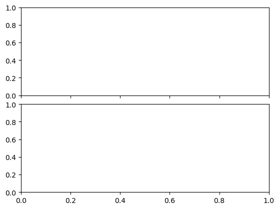

#### Now that we have that axis value specified, annotate the position and marker for VO2 max

#### For the first plot ax[0] we create the lable and make it red

Then we get rid of the right and top plot frame We set the y axis lab as "L/min" and tell it to print a legend

#### Same thing for the second plot *note* we don't see the plot because we have not ploted the plot

#### We can now create a file with our first plot! We will save the plot first for reasons discussed

#### As this is an interactive space we need to put all the code together for it to plot out interactively...

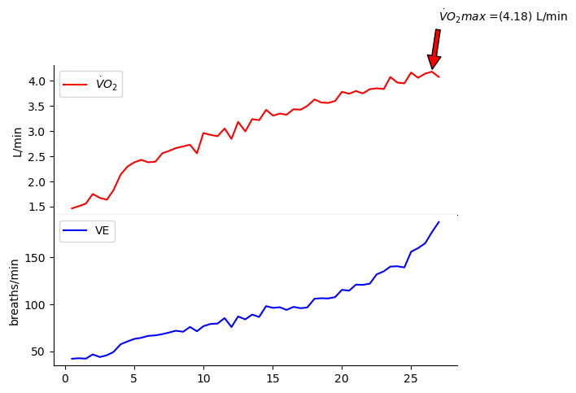

### We can put this all together now in one code block that does everything...

We have built up each part seperatly in the code above to make sure that all parts of our code should and do work. Now that we know everything works we can take the next step of putting it together in one code block so we don't run into coherence problems (running things out of order). We will run everything in one block now, this is a self contained python file and you could turn it into a .py file and run it from the command line and if your path to the datafile was accurate it would run and save the image file.

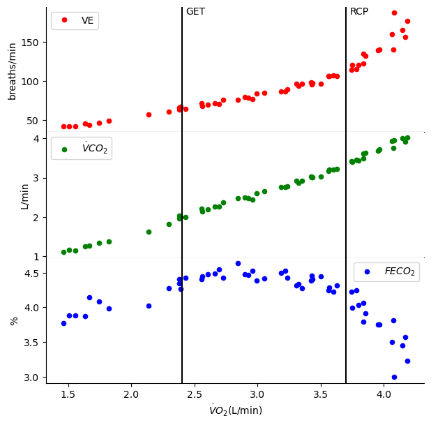

### Please note that if you change the file path of the datafile in the code block above you create an completely new graph for your new data, all by changing just one line of code...

Also I have changed the marker form a line to dots, can you see somthing about the data that was hidden before when it was plotted in lines?